# Change Detection on EO Imagery

### DeepLabV3 vs Simple U-Net vs Siamese U-Net vs ChangeFormer (LEVIR-CD Dataset)

## Objective

This notebook presents a structured comparison of multiple change detection architectures for Earth Observation (EO) imagery.

We evaluate:

- DeepLabV3 (baseline)
- Simple U-Net
- Siamese U-Net (shared encoder, feature-difference fusion)
- ChangeFormer-B0 (transformer-based)

Goal: understand the trade-offs between classical CNN-based change detection, encoder–decoder architectures, and transformer-based models under a controlled setup.

## Workflow

1. Data loading and inspection
2. Image preprocessing
3. Model training (4 architectures)
4. Evaluation and comparison (OA, F1, mIoU)
5. Prediction visualization

## Dataset

We use **a subset of the LEVIR-CD dataset**:

- high-resolution aerial image pairs (before / after)
- RGB imagery (bi-temporal observations per sample)
- pixel-wise binary change masks (change vs. no change)
- building change detection task
- strong class imbalance (changed pixels are sparse)
- resized to a consistent input size

The dataset is split into training, validation, and test sets.

## Data Inspection

Visual inspection to verify image quality, temporal alignment between image pairs, and change mask quality

```python
import torch, torchvision, torchgeo
print("PyTorch:", torch.__version__)
print("TorchVision:", torchvision.__version__)
print("TorchGeo:", torchgeo.__version__)
```

```
PyTorch: 2.10.0+cu126
TorchVision: 0.25.0+cu126
TorchGeo: 0.9.0
```

```python
import os, random, math, warnings
from pathlib import Path
import numpy as np
import matplotlib.pyplot as plt

import torch
import torch.nn as nn
import torch.nn.functional as F

import torch.optim as optim
from torch.utils.data import DataLoader, Subset
import torchvision
from torchvision import transforms
from torchvision.models.segmentation import deeplabv3_resnet50

import segmentation_models_pytorch as smp
from transformers import SegformerForSemanticSegmentation

from torchgeo.datasets import LEVIRCD
from sklearn.metrics import confusion_matrix

warnings.filterwarnings("ignore")

SEED = 42
random.seed(SEED); np.random.seed(SEED); torch.manual_seed(SEED)

device = torch.device("cuda" if torch.cuda.is_available() else "cpu")
print("Using device:", device)
```

```
Using device: cuda
```

```
Files already downloaded and verified
Total samples: 445
```

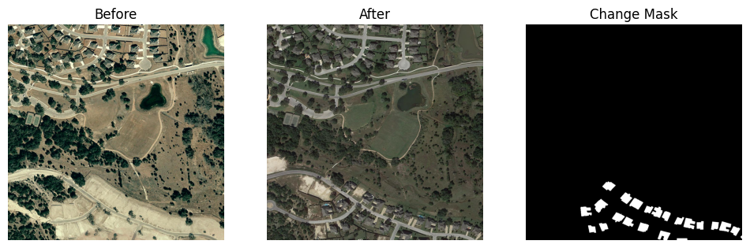

```python
# Load LEVIR-CD dataset
DATA_ROOT = Path("./data/levircd")
DATA_ROOT.mkdir(parents=True, exist_ok=True)

try:
    ds_all = LEVIRCD(root=DATA_ROOT, download=True)
except TypeError:
    ds_all = LEVIRCD(root=DATA_ROOT)

print("Total samples:", len(ds_all))

# Visual inspection of one image pair
sample = ds_all[0]
before, after, label = sample["image"][0], sample["image"][1], sample["mask"][0]

before_img = np.transpose(before.numpy(), (1, 2, 0)).astype(np.uint8)
after_img  = np.transpose(after.numpy(), (1, 2, 0)).astype(np.uint8)
label_img  = label.numpy().astype(np.uint8)

fig, axes = plt.subplots(1, 3, figsize=(12, 4))
axes[0].imshow(before_img)
axes[0].set_title("Before"); axes[0].axis("off")
axes[1].imshow(after_img)
axes[1].set_title("After"); axes[1].axis("off")
axes[2].imshow(label_img, cmap="gray")
axes[2].set_title("Change Mask"); axes[2].axis("off")
plt.show()
plt.tight_layout()
```

## Image Preprocessing

Bi-temporal pair preparation (before / after images + change mask)

```python
# Train / Validation / Test split (60 / 20 / 20) on full dataset
indices = list(range(len(ds_all)))
random.shuffle(indices)
n_train = int(0.6*len(indices))
n_val = int(0.2*len(indices))
train_idx, val_idx, test_idx = indices[:n_train], indices[n_train:n_train+n_val], indices[n_train+n_val:]

print(f"Train: {len(train_idx)}, Val: {len(val_idx)}, Test: {len(test_idx)}")

from torchvision import transforms
import torchvision.transforms.functional as TF

tf_img = transforms.Compose([
    transforms.Resize((512, 512)),
])

# Resize input image pairs (before/after); masks resized with nearest interpolation to preserve labels
class ChangeDataset(torch.utils.data.Dataset):
    def __init__(self, base, indices, tf_img=None, size=512):
        self.base = base
        self.indices = indices
        self.tf_img = tf_img
        self.size = size

    def __len__(self):
        return len(self.indices)

    def __getitem__(self, idx):
        sample = self.base[self.indices[idx]]
        img1, img2, mask = sample["image"][0], sample["image"][1], sample["mask"][0]

        if isinstance(img1, torch.Tensor):
            img1 = TF.resize(img1, (self.size, self.size))
            img2 = TF.resize(img2, (self.size, self.size))
        if isinstance(mask, torch.Tensor):
            mask = TF.resize(mask.unsqueeze(0), (self.size, self.size), interpolation=TF.InterpolationMode.NEAREST).squeeze(0)

        img = torch.cat([img1, img2], dim=0)  # [6, H, W]
        mask = mask.long()                    # [H, W]

        return img, mask


train_ds = ChangeDataset(ds_all, train_idx, tf_img=tf_img)
val_ds   = ChangeDataset(ds_all, val_idx, tf_img=tf_img)
test_ds  = ChangeDataset(ds_all, test_idx, tf_img=tf_img)

train_loader = DataLoader(train_ds, batch_size=4, shuffle=True)
val_loader   = DataLoader(val_ds, batch_size=4)
test_loader  = DataLoader(test_ds, batch_size=4)
```

```
Train: 267, Val: 89, Test: 89
```

## Model training (4 architectures)

DeepLabV3-ResNet50 (baseline), Simple U-Net and Siamese U-Net (both with ResNet50 encoder), and ChangeFormer-B0 are trained under a unified pipeline

```python
# Unified training setup across all architectures for fair comparison
model_name = "changeformer"   # "deeplabv3" | "unet" | "siamese_unet" | "changeformer"

if model_name == "deeplabv3":
    model = deeplabv3_resnet50(weights=None, num_classes=2)
    model.backbone.conv1 = nn.Conv2d(6, 64, kernel_size=7, stride=2, padding=3, bias=False)

elif model_name == "unet":
    model = smp.Unet(
        encoder_name="resnet50",
        encoder_weights=None,
        in_channels=6,
        classes=2
    )

elif model_name == "siamese_unet":
    class SiameseUNet(nn.Module):
        def __init__(self):
            super().__init__()

            base_model = smp.Unet(
                encoder_name="resnet50",
                encoder_weights=None,
                in_channels=3,
                classes=2
            )

            self.encoder = base_model.encoder
            self.decoder = base_model.decoder
            self.segmentation_head = base_model.segmentation_head

        def forward(self, img1, img2):
            feat1 = self.encoder(img1)
            feat2 = self.encoder(img2)

            fused_feats = [torch.abs(f1 - f2) for f1, f2 in zip(feat1, feat2)]

            decoder_output = self.decoder(fused_feats)
            masks = self.segmentation_head(decoder_output)
            return masks

    model = SiameseUNet()

elif model_name == "changeformer":
    model = SegformerForSemanticSegmentation.from_pretrained(
        "nvidia/segformer-b0-finetuned-ade-512-512",
        num_labels=2,
        ignore_mismatched_sizes=True
    )
    model.segformer.encoder.patch_embeddings[0].proj = nn.Conv2d(
        6, 32, kernel_size=7, stride=4, padding=3
    )

model = model.to(device)

criterion = nn.CrossEntropyLoss(weight=torch.tensor([1.0, 1.5]).to(device))
optimizer = optim.Adam(model.parameters(), lr=1e-4)
scheduler = optim.lr_scheduler.StepLR(optimizer, step_size=5, gamma=0.5)
```

[output not shown]

```python
# Handle different output formats across architectures
def forward_pass(model, imgs, masks=None):
    if model_name == "deeplabv3":
        return model(imgs)["out"]

    elif model_name == "unet":
        return model(imgs)

    elif model_name == "siamese_unet":
        img1 = imgs[:, :3]
        img2 = imgs[:, 3:]
        return model(img1, img2)

    elif model_name == "changeformer":
        out = model(pixel_values=imgs).logits
        if masks is not None:
            out = F.interpolate(out, size=masks.shape[-2:], mode="bilinear", align_corners=False)
        return out


def evaluate(loader):
    model.eval()
    y_true, y_pred = [], []

    with torch.no_grad():
        for imgs, masks in loader:
            imgs, masks = imgs.to(device), masks.to(device)
            out = forward_pass(model, imgs, masks)
            preds = out.argmax(1)

            y_true.extend(masks.cpu().numpy().ravel())
            y_pred.extend(preds.cpu().numpy().ravel())

    y_true, y_pred = np.array(y_true), np.array(y_pred)
    cm = confusion_matrix(y_true, y_pred, labels=[0, 1])

    acc = np.diag(cm).sum() / cm.sum()
    iou = np.diag(cm) / (cm.sum(1) + cm.sum(0) - np.diag(cm) + 1e-6)
    f1 = 2 * np.diag(cm) / (cm.sum(1) + cm.sum(0) + 1e-6)

    return acc, iou, f1


EPOCHS = 20
best_miou = 0.0
best_path = f"best_{model_name}_levircd.pth"

for epoch in range(EPOCHS):
    model.train()
    losses = []

    for imgs, masks in train_loader:
        imgs, masks = imgs.to(device), masks.to(device)

        optimizer.zero_grad()
        out = forward_pass(model, imgs, masks)
        loss = criterion(out, masks)
        loss.backward()
        optimizer.step()

        losses.append(loss.item())

    # Validation
    val_acc, val_iou, val_f1 = evaluate(val_loader)
    miou = val_iou.mean()

    print(
        f"Epoch {epoch+1}/{EPOCHS}, "
        f"Loss={np.mean(losses):.4f}, "
        f"Val OA={val_acc:.4f}, mIoU={miou:.4f}, F1={val_f1.mean():.4f}"
    )

    if miou > best_miou:
        best_miou = miou

        # Optional: save best model checkpoint
        # Disabled by default to avoid unintended overwrites during repeated experiments

        # torch.save(model.state_dict(), best_path)
        # print(f"Saved new best model: {best_path} (mIoU={best_miou:.4f})")

    scheduler.step()
```

[output not shown]

## Evaluation

```python
# Load best model
best_path = f"best_{model_name}_levircd.pth"

state_dict = torch.load(best_path, map_location=device, weights_only=True)
model.load_state_dict(state_dict)
model.eval()

# Final evaluation
oa, iou, f1 = evaluate(test_loader)

print(f"Test Overall Accuracy: {oa:.4f}")
print("Per-class IoU:", np.round(iou, 4))
print(f"Mean IoU (mIoU): {iou.mean():.4f}")
print("Per-class F1:", np.round(f1, 4))
print(f"Mean F1: {f1.mean():.4f}")
```

```
Test Overall Accuracy: 0.9774
Per-class IoU: [0.9767 0.575 ]
Mean IoU (mIoU): 0.7758
Per-class F1: [0.9882 0.7301]
Mean F1: 0.8592
```

## Experimental Notes

Several factors were evaluated to identify what drives change detection performance.

- Optimizer and LR tuning showed no meaningful improvement. Changing Adam to AdamW/SGD and varying learning rates did not improve performance → baseline already well-tuned.
- StepLR provided minor improvement in change-class F1/IoU, while cosine decay did not → stable convergence matters more than schedule complexity.
- Class weighting is critical. Moderate weighting (~1.5) improves detection; under-weighting increases FN, over-weighting increases FP.
- Data augmentation was generally harmful. RandomCrop removes spatial context; horizontal flipping provides limited benefit due to inherent orientation invariance in aerial imagery; ColorJitter introduces false change signals → consistency is more important than diversity.
- Model complexity does not ensure improvement. Simple U-Net performs competitively due to strong spatial detail preservation, while Siamese U-Net provides no benefit over simple concatenation.
- Transformer-based models (ChangeFormer) achieve strong peak performance but do not show consistent advantage in limited-data settings.
- Increasing resolution (256 → 512) improves performance across models, with the largest gain in DeepLabV3 due to multi-scale context modeling (ASPP). Higher resolution provides larger effective context, improving detection of small or spatially scattered building changes.
- Longer training gives diminishing returns. 10 → 30 epochs improves slightly but increases cost.
- Overall, performance is driven by spatial context and class imbalance handling, rather than optimizer choice or architectural complexity.

## Visualization

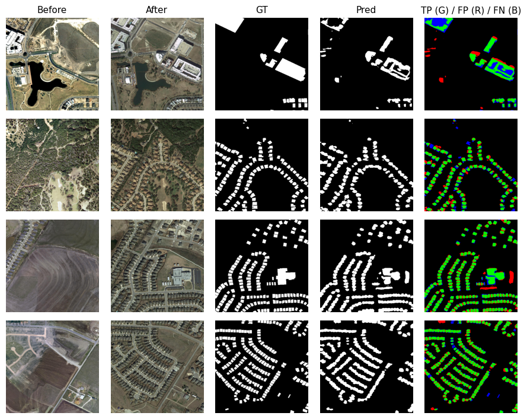

```python
# Prediction visualization on test samples
model.eval()

show_indices = [7, 10, 46, 82]  # representative samples (fixed for comparison)
N = len(show_indices)

fig, axes = plt.subplots(N, 5, figsize=(9, 1.75 * N))

for row, idx in enumerate(show_indices):
    img, mask = test_ds[idx]

    with torch.no_grad():
        imgs = img.unsqueeze(0).to(device)
        mask_t = mask.unsqueeze(0).to(device)
        pred = forward_pass(model, imgs, mask_t).argmax(1).squeeze().cpu().numpy()

    mask = mask.numpy()
    img1 = img[:3].permute(1, 2, 0).numpy()
    img2 = img[3:].permute(1, 2, 0).numpy()

    # TP / FP / FN
    tp = (pred == 1) & (mask == 1)
    fp = (pred == 1) & (mask == 0)
    fn = (pred == 0) & (mask == 1)

    overlay = np.zeros((*pred.shape, 3), dtype=np.uint8)
    overlay[tp] = [0, 255, 0] # Green = True Positive
    overlay[fp] = [255, 0, 0] # Red = False Positive
    overlay[fn] = [0, 0, 255] # Blue = False Negative

    axes[row, 0].imshow(img1.astype(np.uint8))
    axes[row, 1].imshow(img2.astype(np.uint8))
    axes[row, 2].imshow(mask, cmap="gray")
    axes[row, 3].imshow(pred, cmap="gray")
    axes[row, 4].imshow(overlay)

    for col in range(5):
        axes[row, col].axis("off")

titles = ["Before", "After", "GT", "Pred", "TP (G) / FP (R) / FN (B)"]
for col in range(5):
    axes[0, col].set_title(titles[col], fontsize=11)

plt.tight_layout(pad=0.5, w_pad=0.0, h_pad=1.0)
plt.show()
```

## Model Comparison

| Model | Input Size | OA | mIoU | Mean F1 | Strength | Limitation |
| --- | --- | --- | --- | --- | --- | --- |
| DeepLabV3 | 256×256 | 0.96 | 0.69 | 0.78 | Strong multi-scale context modeling (ASPP) | Sensitive to resolution (weaker at lower resolution) |
| DeepLabV3 | 512×512 | 0.98 | 0.77 | 0.86 | Effective context aggregation at higher resolution | Higher computational cost |
| Simple U-Net | 256×256 | 0.97 | 0.69 | 0.79 | Stable baseline, strong spatial detail preservation | Limited global context |
| Simple U-Net | 512×512 | 0.97 | 0.75 | 0.84 | Improved spatial detail with higher resolution | Limited global context |
| Siamese U-Net | 256×256 | 0.96 | 0.64 | 0.73 | Explicit temporal comparison | No gain over simple concatenation |
| Siamese U-Net | 512×512 | 0.97 | 0.70 | 0.79 | Explicit temporal comparison | No gain over simple concatenation |
| ChangeFormer-B0 | 256×256 | 0.97 | 0.70 | 0.80 | Global context modeling (transformer) | Limited data efficiency / inconsistent gains in small data |
| ChangeFormer-B0 | 512×512 | 0.98 | 0.78 | 0.86 | Strong global context modeling at higher resolution | Higher complexity with limited consistency gains |

Key Observations

- Performance depends on architecture–resolution interaction, not model complexity alone
- U-Net remains competitive at 256×256 due to spatial detail preservation
- DeepLabV3 benefits significantly from higher resolution via multi-scale context modeling
- Siamese design provides no advantage over simple input concatenation
- ChangeFormer-B0 achieves the best results at 512×512, but without consistent gains relative to its complexity
- Change-class metrics (F1/IoU) reveal differences more clearly than OA under class imbalance

## Conclusion

This study shows that, under limited-data conditions, improvements come from effective context use and balanced loss design, while more complex architectures provide only marginal or inconsistent benefits relative to their cost.